# 独立2群の検定ひな型

2025-11-26

### データ読み込み

データファイルを開く。  
今回はタブ区切りなので以下のような命令を使う。

```r
kadai <- read.delim("kadai.txt", stringsAsFactors=TRUE)
# 列Genotypeは文字列（string）だがfactor（因子）として読み込まれる
```

## 課題1: SW5がGenotypeごとに異なるかどうかを検定しなさい。

### データの分布を確認（SW5）

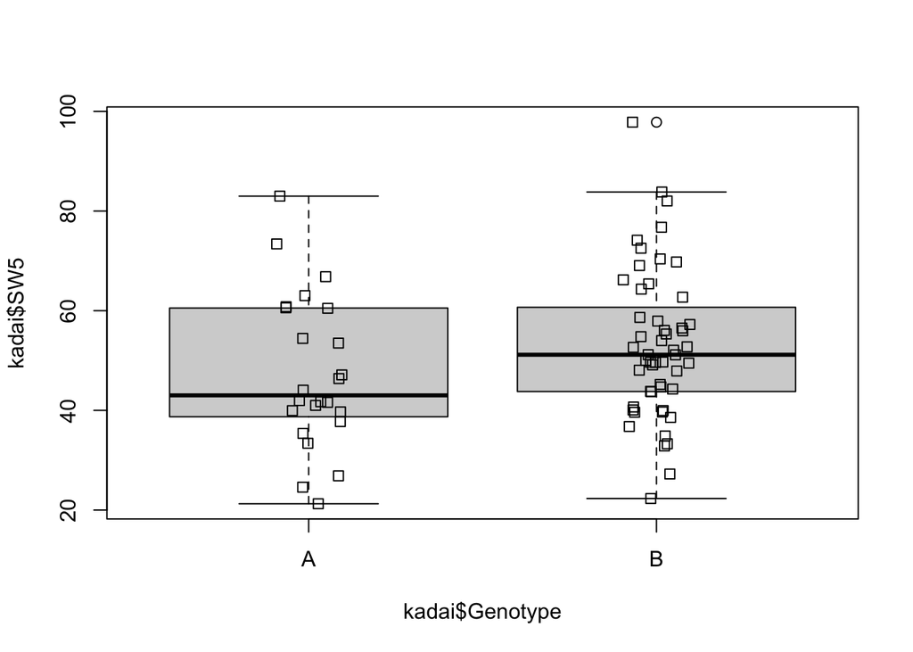

```r
#### グラフを描いている
# boxplotを描いてみる
boxplot(kadai$SW5~kadai$Genotype)
# boxplotの上にドットプロットを重ねて描く
stripchart(kadai$SW5~kadai$Genotype,
vertical=TRUE, # 縦に
method="jitter", # 近い点はランダムにずらす
add=TRUE) # 前のグラフに追加（上書き）
```

### 等分散性の検定

AとBが等分散かどうかを検定する。

```r
# 等分散性の検定
var.test(kadai$SW5~kadai$Genotype)
```

```
##
##  F test to compare two variances
##
## data:  kadai$SW5 by kadai$Genotype
## F = 1.0837, num df = 23, denom df = 51, p-value = 0.7865
## alternative hypothesis: true ratio of variances is not equal to 1
## 95 percent confidence interval:
##  0.5588484 2.3129868
## sample estimates:
## ratio of variances
##           1.083738
```

P=0.786(>0.05)なので有意ではない（等分散とみなせる）

### 等分散性を仮定したt検定（Studentのt検定）

等分散性を仮定して独立2群の平均の差を検定するStudentのt検定を行う。

```r
# 等分散を仮定した独立2群のt検定
t.test(kadai$SW5~kadai$Genotype,
alternative="two.sided", # 両側検定
#paired=FALSE, # 対応なし（独立2群）~を使う場合は指定できない。
var.equal=TRUE, # 等分散を仮定する
conf.level=0.95) # 有意水準5%
```

```
##
##  Two Sample t-test
##
## data:  kadai$SW5 by kadai$Genotype
## t = -1.5288, df = 74, p-value = 0.1306
## alternative hypothesis: true difference in means between group A and group B is not equal to 0
## 95 percent confidence interval:
##  -13.07035   1.72139
## sample estimates:
## mean in group A mean in group B
##        47.45131        53.12579
```

p=0.131（>0.05）なので、遺伝子型AとBとでSW5の差はない。

### 等分散性を仮定しないt検定（Welchのt検定）

等分散性を考慮しないで独立2群の平均の差を検定するWelchのt検定を行う。

```r
# Welchの等分散を仮定しない独立2群のt検定
t.test(kadai$SW5~kadai$Genotype,
alternative="two.sided", # 両側検定
#paired=FALSE, # 対応なし（独立2群）~を使う場合は指定できない。
var.equal=FALSE, # 等分散を仮定しない
conf.level=0.95) # 有意水準5%
```

```
##
##  Welch Two Sample t-test
##
## data:  kadai$SW5 by kadai$Genotype
## t = -1.506, df = 43.226, p-value = 0.1393
## alternative hypothesis: true difference in means between group A and group B is not equal to 0
## 95 percent confidence interval:
##  -13.272034   1.923078
## sample estimates:
## mean in group A mean in group B
##        47.45131        53.12579
```

等分散の場合、等分散のt検定とWelchのt検定のp値はほぼ同じになる。

p=0.139(>0.05)なので、遺伝子型AとBとでSW5の差はない。

## 課題2: SW35がGenotypeごとに異なるかどうかを検定しなさい。

### データの分布を確認（SW35）

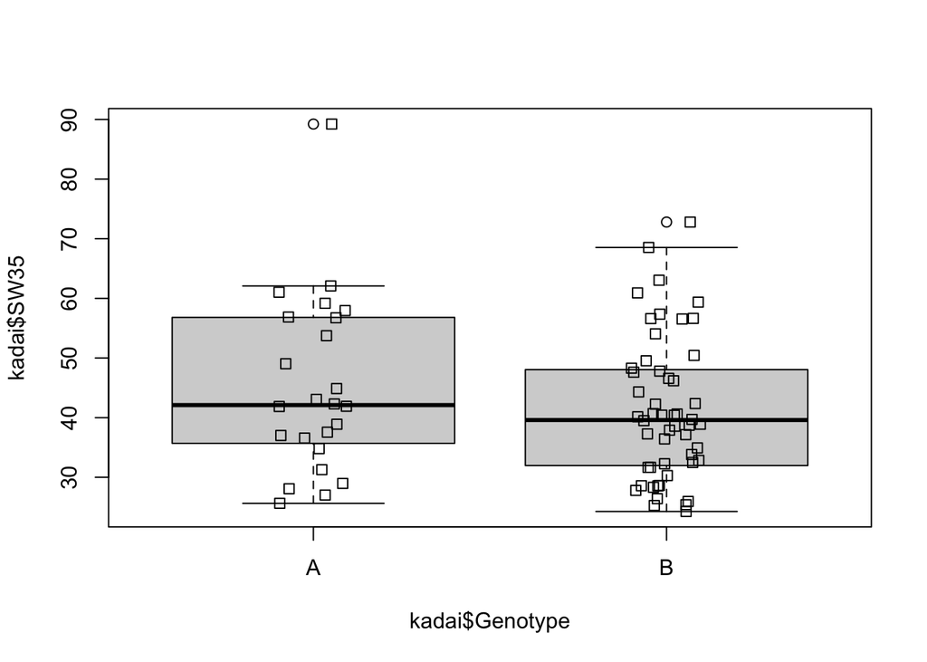

```r
# boxplot
boxplot(kadai$SW35~kadai$Genotype)
# boxplotの上にドットプロットを重ねて描く
stripchart(kadai$SW35~kadai$Genotype,
vertical=TRUE, # 縦に
method="jitter", # 近い点はランダムにずらす
add=TRUE) # 前のグラフに追加（上書き）
```

### 等分散性の検定

AとBが等分散かどうかを検定する。

```r
# 等分散性の検定
var.test(kadai$SW35~kadai$Genotype)
```

```
##
##  F test to compare two variances
##
## data:  kadai$SW35 by kadai$Genotype
## F = 1.5483, num df = 23, denom df = 51, p-value = 0.1947
## alternative hypothesis: true ratio of variances is not equal to 1
## 95 percent confidence interval:
##  0.7984144 3.3045133
## sample estimates:
## ratio of variances
##           1.548313
```

### 等分散性を仮定したt検定（Studentのt検定）

等分散性を仮定して独立2群の平均の差を検定するStudentのt検定を行う。

```r
# 等分散を仮定した独立2群のt検定
t.test(kadai$SW35~kadai$Genotype,
alternative="two.sided", # 両側検定
#paired=FALSE, # 対応なし（独立2群）~を使う場合は指定できない。
var.equal=TRUE, # 等分散を仮定する
conf.level=0.95) # 有意水準5%
```

```
##
##  Two Sample t-test
##
## data:  kadai$SW35 by kadai$Genotype
## t = 1.2455, df = 74, p-value = 0.2169
## alternative hypothesis: true difference in means between group A and group B is not equal to 0
## 95 percent confidence interval:
##  -2.371449 10.279329
## sample estimates:
## mean in group A mean in group B
##        45.24182        41.28788
```

### 等分散性を仮定しないt検定（Welchのt検定）

等分散性を考慮しないで独立2群の平均の差を検定するWelchのt検定を行う。

```r
# Welchの等分散を仮定しない独立2群のt検定
t.test(kadai$SW35~kadai$Genotype,
alternative="two.sided", # 両側検定
#paired=FALSE, # 対応なし（独立2群）~を使う場合は指定できない。
var.equal=FALSE, # 等分散を仮定しない
conf.level=0.95) # 有意水準5%
```

```
##
##  Welch Two Sample t-test
##
## data:  kadai$SW35 by kadai$Genotype
## t = 1.1491, df = 37.263, p-value = 0.2579
## alternative hypothesis: true difference in means between group A and group B is not equal to 0
## 95 percent confidence interval:
##  -3.016536 10.924416
## sample estimates:
## mean in group A mean in group B
##        45.24182        41.28788
```

## 課題3: SW5-SW35（SW5_35）がGenotypeごとに異なるかどうかを検定しなさい。

### データの分布を確認（SW5_35）

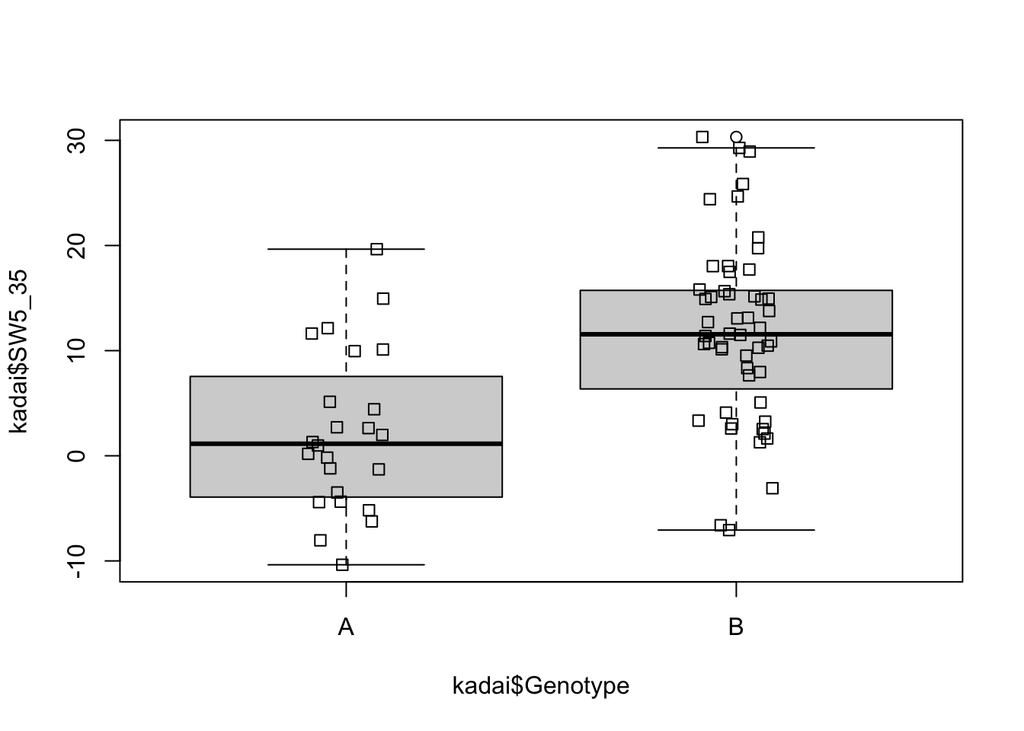

```r
# boxplot
boxplot(kadai$SW5_35~kadai$Genotype)
# boxplotの上にドットプロットを重ねて描く
stripchart(kadai$SW5_35~kadai$Genotype,
vertical=TRUE, # 縦に
method="jitter", # 近い点はランダムにずらす
add=TRUE) # 前のグラフに追加（上書き）
```

### 等分散性の検定

AとBが等分散かどうかを検定する。

```r
# 等分散性の検定
var.test(kadai$SW5_35~kadai$Genotype)
```

```
##
##  F test to compare two variances
##
## data:  kadai$SW5_35 by kadai$Genotype
## F = 0.81339, num df = 23, denom df = 51, p-value = 0.6
## alternative hypothesis: true ratio of variances is not equal to 1
## 95 percent confidence interval:
##  0.4194383 1.7359898
## sample estimates:
## ratio of variances
##          0.8133893
```

### 等分散性を仮定したt検定（Studentのt検定）

等分散性を仮定して独立2群の平均の差を検定するStudentのt検定を行う。

```r
# 等分散を仮定した独立2群のt検定
t.test(kadai$SW5_35~kadai$Genotype,
alternative="two.sided", # 両側検定
#paired=FALSE, # 対応なし（独立2群）~を使う場合は指定できない。
var.equal=TRUE, # 等分散を仮定する
conf.level=0.95) # 有意水準5%
```

```
##
##  Two Sample t-test
##
## data:  kadai$SW5_35 by kadai$Genotype
## t = -4.7593, df = 74, p-value = 9.394e-06
## alternative hypothesis: true difference in means between group A and group B is not equal to 0
## 95 percent confidence interval:
##  -13.659488  -5.597348
## sample estimates:
## mean in group A mean in group B
##        2.209492       11.837910
```

### 等分散性を仮定しないt検定（Welchのt検定）

等分散性を考慮しないで独立2群の平均の差を検定するWelchのt検定を行う。

```r
# Welchの等分散を仮定しない独立2群のt検定
t.test(kadai$SW5_35~kadai$Genotype,
alternative="two.sided", # 両側検定
#paired=FALSE, # 対応なし（独立2群）~を使う場合は指定できない。
var.equal=FALSE, # 等分散を仮定しない
conf.level=0.95) # 有意水準5%
```

```
##
##  Welch Two Sample t-test
##
## data:  kadai$SW5_35 by kadai$Genotype
## t = -4.9457, df = 49.342, p-value = 9.193e-06
## alternative hypothesis: true difference in means between group A and group B is not equal to 0
## 95 percent confidence interval:
##  -13.540005  -5.716831
## sample estimates:
## mean in group A mean in group B
##        2.209492       11.837910
```